# Welch t Tests and CIs: An Example

Companion `R` Code for JB Statistics Video Lesson

Created by Jill E. Thomley

Monday, April 12, 2021 @ 01:09 PM

[video not shown]

### Packages Used

```r
library(tidyverse)
library(infer)
```

### Venom Example

#### Using the `t.test()` Function in `R`

Traditional two-sample t-tests are performed in `R` using the `t.test()` function. However, we need the data values. We do not have the data used in the videos, so here we will use data that was simulated to have means and variances similar to that in the examples. These samples also assume that the null hypothesis is true. The values will vary slightly from the video, but the method is correct. Unpooled variance is the default for the `t.test()` function. You should use `?t.test` to explore the syntax.

$$H_0: \mu_{antivenom} = \mu_{saline}$$

$$H_a: \mu_{antivenom} \neq \mu_{saline}$$

```r
venomdata <- data.frame(group  = c(rep("antivenom", 9),
                                   rep("saline", 8)),
                        volume = c(127.64,
                                   154.67,
                                   174.16,
                                   299.29,
                                   202.54,
                                   237.23,
                                   135.22,
                                   197.94,
                                   273.30,
                                   232.94,
                                   356.82,
                                   243.65,
                                   345.52,
                                   122.21,
                                   171.22,
                                   107.52,
                                   98.24))

venomdata %>%
  group_by(group) %>%
  summarize(xbar = mean(volume),
            s = sd(volume),
            n = n())
```

```
# A tibble: 2 x 4
  group      xbar     s     n
  <fct>     <dbl> <dbl> <int>
1 antivenom  200.  60.0     9
2 saline     210. 103.      8
```

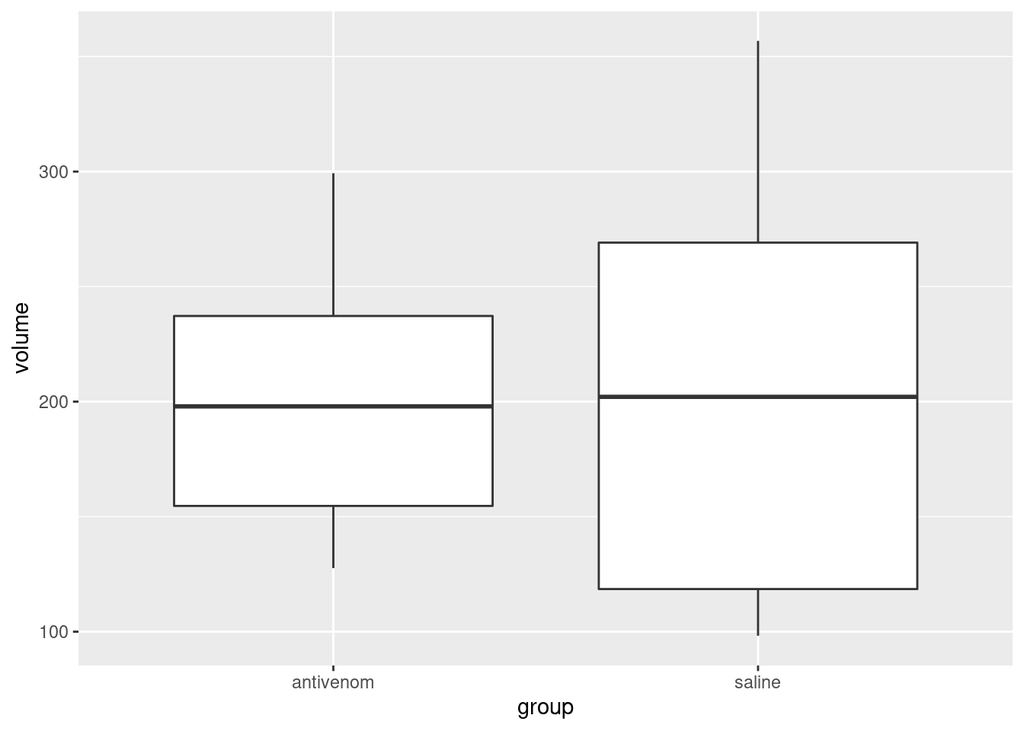

```r
ggplot(venomdata, aes(x = group, y = volume)) +
 geom_boxplot()
```

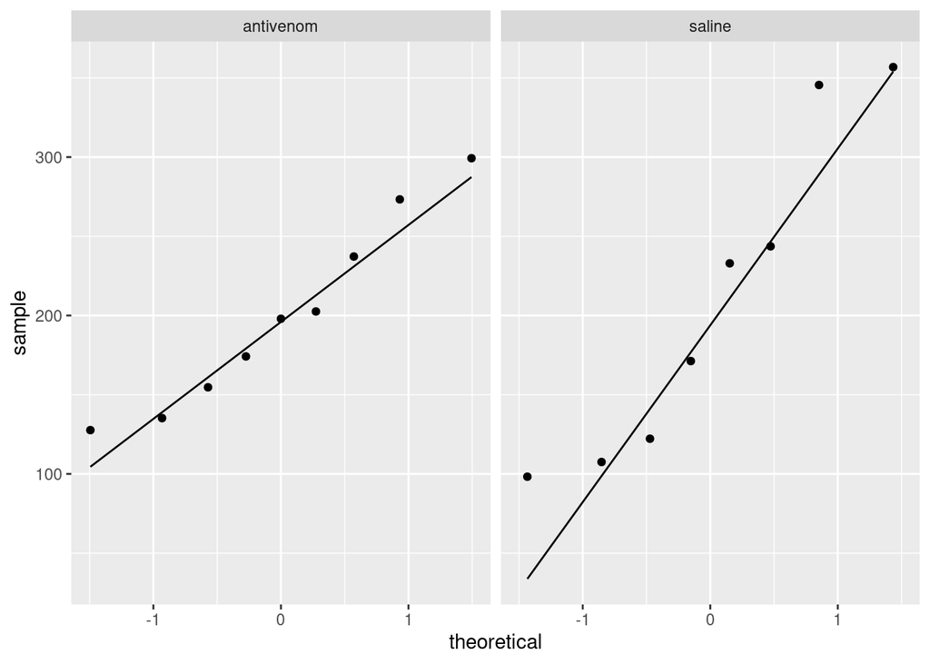

```r
ggplot(venomdata, aes(sample = volume)) +
  geom_qq() +
  geom_qq_line() +
  facet_grid(. ~ group)
```

The data in each group are close enough to approximately normal that we can use the traditional test based on the Central Limit Theorem, despite the small sample sizes. We get both the test and the confidence interval from the `t.test()` function. Looking at the *p*-value of the test, we would fail to reject $H_o$ because the *p*-value is greater than 0.05.

```r
t.test(volume ~ group, data = venomdata, alternative = "two.sided")
```

```
    Welch Two Sample t-test

data:  volume by group
t = -0.2303, df = 11.006, p-value = 0.8221
alternative hypothesis: true difference in means is not equal to 0
95 percent confidence interval:
 -100.74822   81.66045
sample estimates:
mean in group antivenom    mean in group saline
               200.2211                209.7650
```

#### Using `infer` for the Hypothesis Test

We can test the same data using the `infer` package. How are the assumptions of this test different than the traditional test? If the assumptions and conditions for the traditional test are met for the data, the p-values for the traditional and permutation tests will be similar. Notice the shape of the simulated null distribution.

```r
null_distribution <- venomdata %>%
  specify(volume ~ group) %>%
  hypothesize(null = "independence") %>%
  generate(reps = 1000, type = "permute") %>%
  calculate(stat = "diff in means", order = c("antivenom", "saline"))

obs_diff <- venomdata %>%
  specify(volume ~ group) %>%
  calculate(stat = "diff in means", order = c("antivenom", "saline"))
obs_diff
```

```
# A tibble: 1 x 1
   stat
  <dbl>
1 -9.54
```

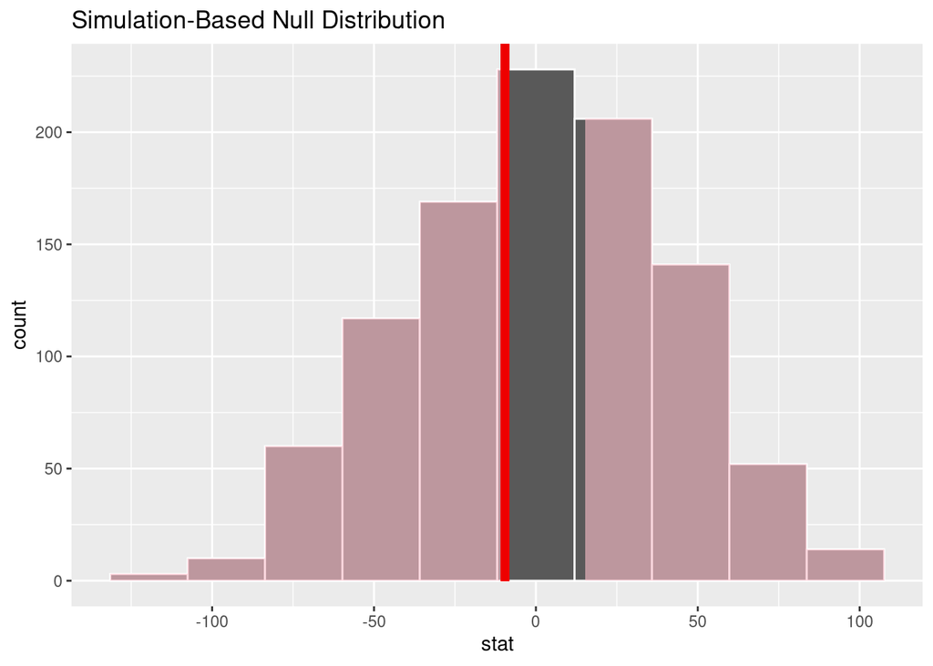

```r
visualize(null_distribution, bins = 10) +
  shade_p_value(obs_stat = obs_diff, direction = "both")
```

```r
null_distribution %>%
  get_p_value(obs_stat = obs_diff, direction = "both")
```

```
# A tibble: 1 x 1
  p_value
    <dbl>
1   0.756
```

#### Using `infer` for a Confidence Interval

We can also use `infer` to find a confidence interval.

```r
bootstrap_distribution <- venomdata %>%
  specify(volume ~ group) %>%
  generate(reps = 1000, type = "bootstrap") %>%
  calculate(stat = "diff in means", order = c("antivenom", "saline"))

obs_diff <- venomdata %>%
  specify(volume ~ group) %>%
  calculate(stat = "diff in means", order = c("antivenom", "saline"))
obs_diff
```

```
# A tibble: 1 x 1
   stat
  <dbl>
1 -9.54
```

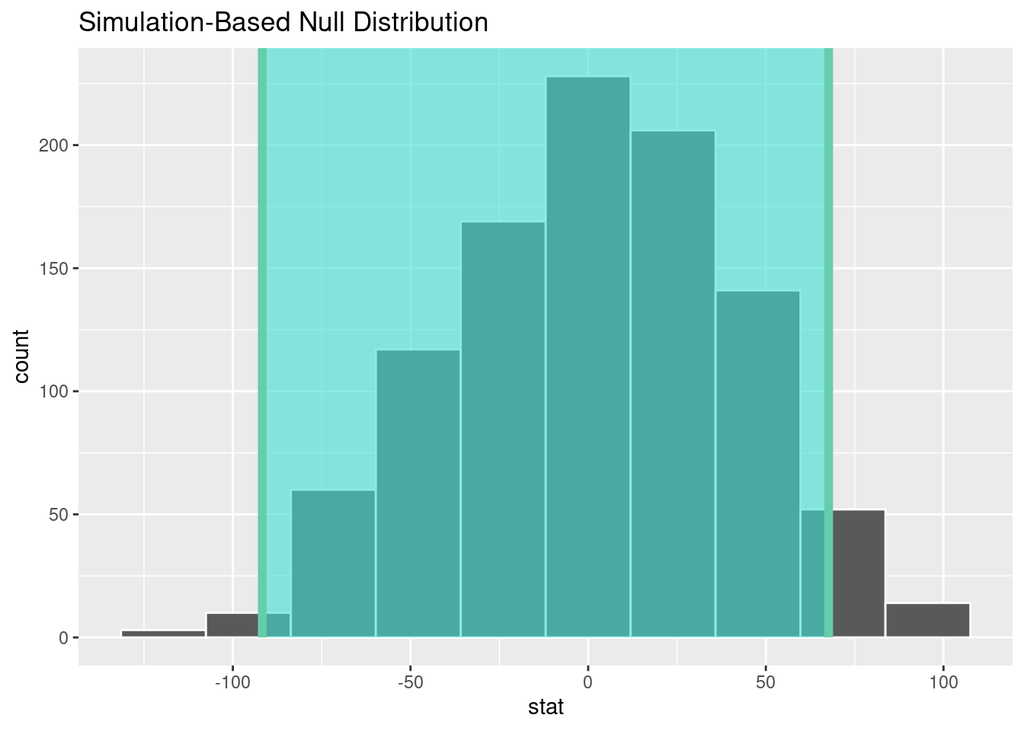

```r
percentile_ci <- bootstrap_distribution %>%
  get_confidence_interval(level = 0.95, type = "percentile")

visualize(null_distribution, bins = 10) +
  shade_confidence_interval(endpoints = percentile_ci)
```